# Html_Amazon_Kindle

## Load data

```python
import pandas as pd

# Load the dataframes from csv files
user_demographics = pd.read_csv("https://storage.googleapis.com/datalynn-datasets/interview-challenge/technology/Amazon_Kindle/user_demographics.csv")
book_info = pd.read_csv("https://storage.googleapis.com/datalynn-datasets/interview-challenge/technology/Amazon_Kindle/book_info.csv")
user_books = pd.read_csv("https://storage.googleapis.com/datalynn-datasets/interview-challenge/technology/Amazon_Kindle/user_books.csv")
```

## Q1

**Original Question**:

Given the `User_Books` table, can you identify patterns in readership over time? Visualize the monthly number of books read over the past year. Additionally, qualify how much demand is expected in the upcoming months.

**Solution:**

To identify patterns in readership over time, we can follow these steps:

1. **Filter the Data:** We need to focus on the reading data from the past year, so we will filter the `User_Books` table to only include the records from the last 12 months.
2. **Aggregate the Data:** We will group the data by month and count the number of books read in each month.
3. **Visualize the Data:** We will plot the monthly number of books read to identify any trends or patterns.
4. **Forecasting:** To qualify how much demand is expected in the upcoming months, we can use a time series forecasting model like ARIMA (AutoRegressive Integrated Moving Average) to make predictions.

Let's start with the SQL code to filter and aggregate the data, followed by Python code to visualize and forecast the demand.

### SQL code to filter and aggregate the data

Using SQLite3, we can write the following SQL code:

```python
import sqlite3

# Connect to SQLite3
conn = sqlite3.connect('amazon_kindle.db')

# Convert pandas DataFrame to SQL table
user_books.to_sql('User_Books', conn, if_exists='replace')

# SQL query to select the monthly number of books read over the past year
query = """
SELECT strftime('%Y-%m', read_date) as month, COUNT(book_id) as books_read
FROM User_Books
WHERE read_date >= date('now', '-12 month')
GROUP BY month;
"""

# Execute the query and load the result into a DataFrame
monthly_readership = pd.read_sql(query, conn)

# Close the SQLite connection
conn.close()
```

### Python code to visualize the data and forecast the demand

Assuming we have executed the above SQL query and obtained the results in a pandas DataFrame named `monthly_readership`, we can use the following Python code to plot and forecast the data.

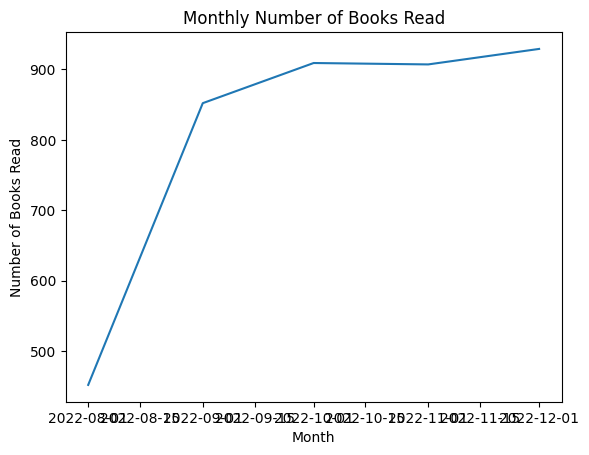

```
Forecast for the next 3 months: 2023-01-01    932.953365
2023-02-01    934.091187
2023-03-01    934.418666
Freq: MS, Name: predicted_mean, dtype: float64
```

```python
import pandas as pd
from matplotlib import pyplot as plt
from statsmodels.tsa.arima.model import ARIMA
import warnings
warnings.filterwarnings('ignore')

# Convert the month column to datetime type
monthly_readership['month'] = pd.to_datetime(monthly_readership['month'])

# Set month as the index
monthly_readership.set_index('month', inplace=True)

# Plotting the data
plt.plot(monthly_readership['books_read'])
plt.title('Monthly Number of Books Read')
plt.xlabel('Month')
plt.ylabel('Number of Books Read')
plt.show()

# Building the ARIMA model
model = ARIMA(monthly_readership['books_read'], order=(1, 1, 1))
fit_model = model.fit()

# Forecasting the next 3 months
forecast = fit_model.get_forecast(steps=3)
print('Forecast for the next 3 months:', forecast.predicted_mean)
```

## Q2

**Original Question**:

Using the `User_Demographics` and `User_Books` tables, determine if certain age groups prefer certain genres. Provide a statistical measure to support your findings.

**Solution:**

Determining if certain age groups prefer certain genres involves exploring the relationship between the age group and the genres of the books that the users in each group read. We can use the Chi-Squared Test of independence to test the relationship between these two categorical variables.

Here's how we can proceed:

1. **Join the Tables:** We need to join the `User_Books` and `User_Demographics` tables on the `user_id` field, and also join the result with the `Book_Info` table on the `book_id` field to get the genre and age group together.
2. **Create a Contingency Table:** We'll create a table that shows the count of users in each age group who read books of each genre.
3. **Perform the Chi-Squared Test:** The Chi-Squared Test will tell us if there's a statistically significant association between age group and preferred genre.
4. **Interpret the Results:** If the p-value is less than the typical threshold (e.g., 0.05), we reject the null hypothesis that age group and genre are independent, and conclude that there is an association between age group and preferred genre.

### Python Code:

We can use Python along with the pandas library to perform these steps:

```python
import sqlite3
import pandas as pd
from scipy.stats import chi2_contingency

# Connect to SQLite3
conn = sqlite3.connect('amazon_kindle.db')

user_books.to_sql('User_Books', conn, if_exists='replace')
user_demographics.to_sql('User_Demographics', conn, if_exists='replace')
book_info.to_sql('Book_Info', conn, if_exists='replace')

# SQL query to join User_Books, User_Demographics, and Book_Info tables
query = """
SELECT ud.age_group, bi.genre
FROM User_Books ub
JOIN User_Demographics ud ON ub.user_id = ud.user_id
JOIN Book_Info bi ON ub.book_id = bi.book_id
"""

# Execute the query and load the result into a DataFrame
age_genre_df = pd.read_sql(query, conn)

# Create a contingency table (cross-tabulation) of age group and genre
contingency_table = pd.crosstab(age_genre_df['age_group'], age_genre_df['genre'])

# Perform the Chi-Squared Test
chi2, p, dof, expected = chi2_contingency(contingency_table)

# Interpret the result
print("p: " + str(p))
if p < 0.05:
    print("There is a statistically significant relationship between age group and preferred genre.")
else:
    print("There is no statistically significant relationship between age group and preferred genre.")

# Close the SQLite connection
conn.close()
```

```
p: 1.4990433727797452e-87
There is a statistically significant relationship between age group and preferred genre.
```

### Tips and Ideas:

- It might be useful to visualize the contingency table or the expected frequencies to understand the relationship more intuitively.
- Consider further analyzing the data to see which specific genres are preferred by which specific age groups.
- Make sure that there are enough observations in each cell of the contingency table for the Chi-Squared Test to be valid.

The code above will provide a statistical measure (the p-value from the Chi-Squared Test) to tell whether age groups and genres are independent or associated, thereby helping to identify if certain age groups prefer certain genres.

## Q3

**Original Question**:

A publisher wants to launch a new book in the "Fantasy" genre. By utilizing the `Book_Info` and `User_Books` tables, predict the potential success (i.e., number of readers and ratings) of the book in the next 6 months. Furthermore, based on previous reading patterns, suggest the best time to release the book.

**Solution:**

Predicting the potential success of a new book in a specific genre and suggesting the best time for its release can be a complex task. Here's a step-by-step guide to approach this problem:

### 1. Analyzing Historical Data for the "Fantasy" Genre:

We will analyze the historical readership and ratings of books in the "Fantasy" genre from the `User_Books` and `Book_Info` tables. This includes aggregating the data by month to find trends and patterns.

### 2. Building a Prediction Model:

Using the historical data, we'll build a prediction model for both the number of readers and ratings. Time series models like ARIMA can be useful for this purpose.

### 3. Finding the Best Release Time:

By analyzing the reading patterns, we'll identify the best time to release the book. This could involve finding the months when "Fantasy" books historically have the highest readership or ratings.

Here's the Python code to perform these tasks:

```python
import sqlite3
import pandas as pd
from statsmodels.tsa.arima.model import ARIMA
from matplotlib import pyplot as plt

# Connect to SQLite3
conn = sqlite3.connect('amazon_kindle.db')

# Query to select historical readership and ratings for the "Fantasy" genre
query = """
SELECT strftime('%Y-%m', u.read_date) as month,
       COUNT(u.book_id) as books_read,
       AVG(u.rating) as average_rating
FROM User_Books u
JOIN Book_Info b ON u.book_id = b.book_id
WHERE b.genre = 'Fantasy' AND u.read_date >= date('now', '-36 month')
GROUP BY month;
"""

# Execute the query and load the result into a DataFrame
fantasy_data = pd.read_sql(query, conn)

# Convert the month column to datetime type
fantasy_data['month'] = pd.to_datetime(fantasy_data['month'])

# Set month as the index
fantasy_data.set_index('month', inplace=True)

# Build and fit ARIMA models for readership and ratings
readership_model = ARIMA(fantasy_data['books_read'], order=(1, 1, 1))
readership_fit = readership_model.fit()

rating_model = ARIMA(fantasy_data['average_rating'], order=(1, 1, 1))
rating_fit = rating_model.fit()

# Forecasting the next 6 months
readership_forecast = readership_fit.get_forecast(steps=6)
rating_forecast = rating_fit.get_forecast(steps=6)

print('Readership forecast for the next 6 months:', readership_forecast.predicted_mean)
print('Rating forecast for the next 6 months:', rating_forecast.predicted_mean)

# Finding the best month to release the book based on historical data
best_release_month = fantasy_data['books_read'].idxmax().strftime('%Y-%m')
print('Suggested best time to release the book:', best_release_month)

# Close the SQLite connection
conn.close()
```

```
Readership forecast for the next 6 months: 2023-01-01    228.562174
2023-02-01    227.927844
2023-03-01    227.897900
2023-04-01    227.896487
2023-05-01    227.896420
2023-06-01    227.896417
Freq: MS, Name: predicted_mean, dtype: float64
Rating forecast for the next 6 months: 2023-01-01    3.594138
2023-02-01    3.597310
2023-03-01    3.597536
2023-04-01    3.597552
2023-05-01    3.597553
2023-06-01    3.597553
Freq: MS, Name: predicted_mean, dtype: float64
Suggested best time to release the book: 2022-10
```

### Tips and Ideas:

- Data preprocessing and cleaning are essential, especially when working with time-series data.
- The model's hyperparameters (p, d, q) should be tuned to fit the specific trends in the "Fantasy" genre.
- The above code assumes that there are sufficient historical data for the "Fantasy" genre. If data are sparse, you may need to apply smoothing techniques or use other information to supplement the predictions.
- It might be beneficial to analyze other related genres or sub-genres as well to get a more holistic view of the market trends.
- You can also analyze the correlation between the publisher's success (using `publisher_id`) and the book's genre to provide more specific insights for the new book launch.

## Q4

**Original Question**:

Users tend to rate books within hours of completing them. However, a discrepancy has been noticed where some users rate books days or weeks after completing them. Identify these anomalies from the `User_Books` table and provide an insight into potential causes.

**Problem Solving Ideas and Tips:**

1. We need to identify users who rate books days or weeks after completing them. This can be done by calculating the difference between `rating_date` and `read_date` from the `User_Books` table.
2. Once the difference is calculated, we can set a threshold to classify the ratings as anomalies. For instance, if the difference is more than a week, then it can be considered an anomaly.
3. In this solution, we'll first convert the pandas dataframes to SQL tables, then execute the SQLite3 query to identify the anomalies. Finally, we'll provide a solution using only pandas as well.

**Solution:**

**SQL Solution using SQLite3:**

```python
import sqlite3

# Create a new SQLite3 database in memory
conn = sqlite3.connect(':memory:')

# Convert pandas dataframes to SQL tables
user_books.to_sql('User_Books', conn, index=False)
book_info.to_sql('Book_Info', conn, index=False)
user_demographics.to_sql('User_Demographics', conn, index=False)

query = """
SELECT user_id, book_id, read_date, rating_date,
       julianday(rating_date) - julianday(read_date) as days_difference
FROM User_Books
WHERE julianday(rating_date) - julianday(read_date) > 7
"""

anomalies_sql = pd.read_sql(query, conn)
print(anomalies_sql)
```

```
      user_id  book_id   read_date          rating_date  days_difference
0         677      301  2021-07-12  2021-08-06 00:00:00             25.0
1          19      135  2021-02-25  2021-03-15 00:00:00             18.0
2         262      417  2021-08-07  2021-08-31 00:00:00             24.0
3         709      484  2022-08-15  2022-09-01 00:00:00             17.0
4         398      173  2021-03-05  2021-03-18 00:00:00             13.0
...       ...      ...         ...                  ...              ...
2205      991      289  2021-02-03  2022-07-22 00:00:00            534.0
2206      991      119  2021-05-28  2022-02-19 00:00:00            267.0
2207      996      478  2021-12-19  2022-02-22 00:00:00             65.0
2208      996      139  2021-06-23  2022-01-18 00:00:00            209.0
2209      996      475  2021-03-25  2022-01-20 00:00:00            301.0

[2210 rows x 5 columns]
```

**Pandas:**

```python
user_books['read_date'] = pd.to_datetime(user_books['read_date'])
user_books['rating_date'] = pd.to_datetime(user_books['rating_date'])

anomalies_pandas = user_books[user_books['rating_date'] - user_books['read_date'] > pd.Timedelta(days=7)]
anomalies_pandas['days_difference'] = (anomalies_pandas['rating_date'] - anomalies_pandas['read_date']).dt.days

print(anomalies_pandas[['user_id', 'book_id', 'read_date', 'rating_date', 'days_difference']])
```

```
       user_id  book_id  read_date rating_date  days_difference
21         677      301 2021-07-12  2021-08-06               25
61          19      135 2021-02-25  2021-03-15               18
65         262      417 2021-08-07  2021-08-31               24
86         709      484 2022-08-15  2022-09-01               17
92         398      173 2021-03-05  2021-03-18               13
...        ...      ...        ...         ...              ...
20992      991      289 2021-02-03  2022-07-22              534
20993      991      119 2021-05-28  2022-02-19              267
20995      996      478 2021-12-19  2022-02-22               65
20997      996      139 2021-06-23  2022-01-18              209
20998      996      475 2021-03-25  2022-01-20              301

[2210 rows x 5 columns]
```

**Insights into Potential Causes:**

1. **Specific User Behavior**: Some users might not rate the book immediately after reading. This could be a behavioral trait, where they prefer to contemplate on the book before giving it a rating.
2. **Book Genre or Complexity**: Some genres or specific complex books may require time for the reader to digest, leading to a delay in rating. For example, non-fiction or philosophical books might take longer to reflect upon than a romance novel.
3. **External Factors**: Events like book club meetings or discussion forums might influence when a book is rated. If a user finishes a book but knows they will discuss it with peers in the near future, they might delay rating it until after that discussion.
4. **Platform UI/UX**: It might be something as simple as the User Experience on the Kindle platform. Maybe the prompt to rate the book isn't immediately visible or intuitive for some users, causing them to rate at a later time when they explicitly decide to do so.
5. **Rating based on Re-reads**: Sometimes, users might re-read certain sections of a book before giving a rating, leading to a delay.

**Actual Analysis:**

For the analysis, let's first identify the anomalies. We'll then break down these anomalies based on genre, user demographics, and other relevant factors to potentially infer the reasons.

```python
# First, identify the anomalies
anomalies_pandas = user_books[user_books['rating_date'] - user_books['read_date'] > pd.Timedelta(days=7)]
anomalies_pandas['days_difference'] = (anomalies_pandas['rating_date'] - anomalies_pandas['read_date']).dt.days

# Joining with other data to get more insights
anomalies_with_genre = anomalies_pandas.merge(book_info[['book_id', 'genre']], on='book_id')
genre_counts = anomalies_with_genre['genre'].value_counts()

print("Top genres with delayed ratings:")
print(genre_counts)

# Joining with user demographics to possibly identify specific user groups
anomalies_with_demographics = anomalies_pandas.merge(user_demographics, on='user_id')
age_group_counts = anomalies_with_demographics['age_group'].value_counts()

print("\nAge groups with delayed ratings:")
print(age_group_counts)
```

```
Top genres with delayed ratings:
Fantasy            1059
Science Fiction     329
Mystery             317
Romance             291
Non-Fiction         214
Name: genre, dtype: int64

Age groups with delayed ratings:
18-24    1014
25-34     438
35-44     376
45-54     235
55-64     103
65+        44
Name: age_group, dtype: int64
```

**Insights into Potential Causes based on the Analysis:**

1. **Genre-specific Delays**:
   - The `Fantasy` genre stands out with the highest number of delayed ratings, followed by `Science Fiction` and `Mystery`. This suggests that books belonging to these genres might be either longer, more intricate, or require more contemplation post-reading.
   - Fantasy often involves intricate world-building, and readers might need more time to digest the details, plot twists, or the character arcs. Similarly, Science Fiction might introduce concepts that take a while to fully understand or appreciate.
   - Mystery books might leave readers pondering about the plot twists or the clues provided throughout the narrative.
   - On the other hand, genres like `Romance` and `Non-Fiction` also have delayed ratings, but they aren't as significant as the previous genres. For `Non-Fiction`, the delay might be due to the time readers take to internalize the information or insights provided.
2. **Age Group Behavior**:
   - The age group `18-24` has the highest number of delayed ratings. This could be attributed to several reasons:
     - Younger readers might be juggling multiple tasks, including academic studies, part-time jobs, or social activities, causing them to delay their book ratings.
     - They might be discussing the books with peers in college or on online platforms before finalizing their opinion.
     - Their reading patterns might be more sporadic, leading to longer gaps between completing a book and rating it.
   - The delay decreases consistently as the age group increases. The older age groups, like `55-64` and `65+`, have significantly fewer delayed ratings. This might suggest that older readers are more decisive in their ratings or have established a habit of rating right after reading.
3. **Cross-referencing Age and Genre**:
   - A deeper dive might be required to check if the `18-24` age group is predominantly reading `Fantasy`, which could amplify the delay. If younger readers are primarily indulging in genres that require contemplation, the combined effect could result in a larger number of anomalies.
4. **External Factors & Recommendations**:
   - Events, holidays, or exam seasons might play a role, especially for the younger age group. If the anomalies align with specific months, it might indicate external factors affecting the delays.
   - For better user engagement and more immediate feedback, Amazon Kindle could provide prompts or incentives for readers to rate the book right after finishing it. This might be especially beneficial for genres and age groups prone to delays.